# Lab 11

Brad McNeney

```r
library(tidyverse)
```

In this lab we re-do some of lab 10 using the `map()` functions from `purrr`. Recall that the folder `Lab10Data contains several CSV data files.

```r
dfiles <- dir("Lab10Data",full.names=TRUE)
dfiles
```

```
## [1] "Lab10Data/study1.csv" "Lab10Data/study2.csv" "Lab10Data/study3.csv"
## [4] "Lab10Data/study4.csv" "Lab10Data/study5.csv" "Lab10Data/study6.csv"
## [7] "Lab10Data/study7.csv" "Lab10Data/study8.csv" "Lab10Data/study9.csv"
```

1. Write a function `read_rename_csv()` that (i) reads in a CSV file with `read_csv()` and (ii) changes the names of the columns of the resulting tibble to `c("x","y")`. (Compare to question 2 of lab 10.)

```r
read_rename_csv <- function(df) {
  out <- read_csv(df)
  names(out) <- c("x","y")

  return(out)
}


for (i in seq_along(dfiles)) {
  dat <- read_rename_csv(dfiles[i])
  print(dat)
}
```

```
## # A tibble: 100 x 2
##          x      y
##      <dbl>  <dbl>
##  1 -0.560  -1.77
##  2 -0.230  -1.95
##  3  1.56    1.17
##  4  0.0705 -1.41
##  5  0.129  -2.22
##  6  1.72    1.03
##  7  0.461   0.785
##  8 -1.27   -2.90
##  9 -0.687  -0.972
## 10 -0.446  -2.89
## # ... with 90 more rows
## # A tibble: 150 x 2
```

[output cut: 111 more lines]

2. Use `map()` and `read_rename_csv()` to read and rename all 9 files from the Lab10Data folder.

```r
dat <- dfiles %>% map(read_rename_csv)
```

3. Re-do your call to `map()` from part 2. This time, define the function that reads and renames the data files on the fly, using `~` and `.`. Do you prefer the approach of question 2 or of question 3 (this question)?

Hint: Use `~{ ... }` to define your function, where `...` denotes the body of the function you will define. Remember that `x;y` is equivalent to having `x` and `y` on two lines of R code.

```r
dat <- dfiles %>%
  map(function(df) {out <- read_csv(df); names(out) <- c("x","y"); return(out)})

#dat <- map(dfiles,~{f <- read_csv(.); names(f) <- c("x","y");f})

dat
```

```
## [[1]]
## # A tibble: 100 x 2
##          x      y
##      <dbl>  <dbl>
##  1 -0.560  -1.77
##  2 -0.230  -1.95
##  3  1.56    1.17
##  4  0.0705 -1.41
##  5  0.129  -2.22
##  6  1.72    1.03
##  7  0.461   0.785
##  8 -1.27   -2.90
##  9 -0.687  -0.972
## 10 -0.446  -2.89
## # ... with 90 more rows
##
## [[2]]
## # A tibble: 150 x 2
##          x       y
##      <dbl>   <dbl>
##  1  0.543   0.591
##  2 -0.414   0.0422
##  3 -0.476  -2.40
##  4 -0.789   2.61
##  5 -0.595  -0.146
##  6  1.65    0.990
##  7 -0.0540  0.385
##  8  0.119   1.15
##  9  0.244   0.961
## 10  1.23    0.0638
## # ... with 140 more rows
##
## [[3]]
## # A tibble: 75 x 2
##          x      y
##      <dbl>  <dbl>
##  1 -0.896  -0.959
##  2 -2.07    0.154
##  3  0.150   0.252
##  4 -0.0792 -0.871
```

[output cut: 88 more lines]

```
## [[9]]
## # A tibble: 455 x 2
##          x       y
##      <dbl>   <dbl>
##  1 -0.657   0.408
##  2 -0.466  -0.180
##  3  0.606   1.16
##  4 -0.0395 -0.292
##  5 -0.945   0.902
##  6 -1.51   -0.865
##  7  0.559   2.35
##  8 -1.04   -1.87
##  9  0.497  -0.0935
## 10  0.0731  0.424
## # ... with 445 more rows
```

4. We will now apply the forward pipe several times to get an equivalent to the `plot.study_data()` function you wrote in lab 10. The steps to take are
   1. Pipe `dfiles` through a call to `map()` that reads and renames the files (use your code from either question 2 or 3, whichever you preferred),
   2. pipe the result through `bind_rows(.id="study")` (read the documentation for `bind_rows()`),
   3. pipe the result through `mutate()` to change `study` to a factor, and
   4. pipe the result into `ggplot()` to make the plot.

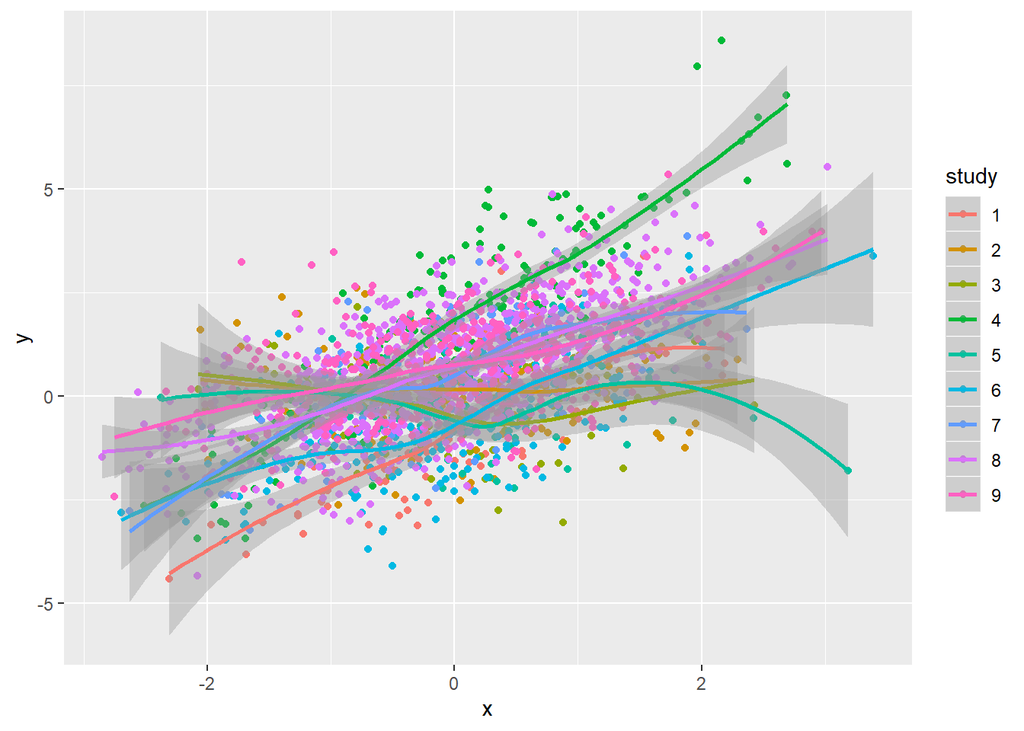

```r
dfiles %>%
  map(read_rename_csv) %>%
  bind_rows(.id="study") %>%
  mutate(study= factor(study)) %>%
  ggplot(mapping=aes(x=x,y=y,color=study)) + geom_point() + geom_smooth()
```